# CASA0005 Week 01 Homework：新西兰受薪雇员地图

2026-10-08

2018 年新西兰 Territorial Authority 的受薪雇员人数地图。属性取自普查 `individual-part-3a` 工作簿的 `Territorial authority` 表，连接到 2018 generalised 行政区边界；不使用 SA1 层级。

计算流程：Excel 字段核对 → 排除汇总记录 → 检查地区代码 → 一对一左连接 → 专题地图。项目入口为课程 `casa0005.Rproj`。普通代码块按顺序构建对象；导出和指定路径渲染保持 `eval=FALSE`。

## 结果摘要

连接后保留 67 个 Territorial Authorities，地区键唯一，就业人数无缺失。Auckland 的受薪雇员人数为 691,473，Christchurch City 为 171,777。这里比较人数，不是就业率。

## 环境

```r
helper <- c("tutorial-tools.R", "../tutorial-tools.R")
helper <- helper[file.exists(helper)]
if (!length(helper)) {
  stop("请先打开课程 casa0005.Rproj，再打开 week01/homework.Rmd。", call. = FALSE)
}
source(helper[[1]])
root <- gis_root()
gis_packages(c("tidyverse", "readxl", "sf", "tmap"))
library(tidyverse)
library(readxl)
library(sf)
library(tmap)
```

### 依赖安装（缺包时）

分析使用 tidyverse、readxl、sf、tmap；安装块保留为独立操作。

```r
options(timeout = 1200)
install.packages("readxl", repos = "https://cloud.r-project.org")
```

## 普查工作簿与字段

工作表 `Territorial authority` 的 AL 列是 2018 Paid employee，第 38 列；2006 和 2013 的同名字段位于其他列。`AL9:AL10` 核对年份及变量，数据从第 11 行开始。

```r
excel_file <- file.path(
  root,
  "data/raw/nz2018/census/2018-SA1-dataset-individual-part-3a-total-NZ_updated_16-7-20.xlsx"
)

file.exists(excel_file)
```

```
## [1] TRUE
```

```r
excel_sheets(excel_file)
```

```
##  [1] "Contents"                      "Geographic key"
##  [3] "Footnotes and symbols"         "SA1"
##  [5] "SA2"                           "Ward"
##  [7] "Local board (Auckland region)" "Territorial authority"
##  [9] "District health board"         "Regional council"
```

```r
read_excel(
  excel_file,
  sheet = "Territorial authority",
  range = "AL9:AL10",
  col_names = FALSE,
  .name_repair = "minimal"
)
```

```
## # A tibble: 2 × 1
##   ``
##   <chr>
## 1 "2018 Census, status in employment,(2)(9)\r\nfor the employed census usually …
## 2 "Paid employee"
```

### 读取就业人数

保留代码、名称和 2018 人数三列。地区代码作为文字保留前导零；对象名 `mycsv` 不表示已经写出 CSV。

```r
census_raw <- read_excel(
  excel_file,
  sheet = "Territorial authority",
  skip = 10,
  col_names = FALSE,
  .name_repair = "minimal"
)

mycsv <- census_raw[, c(1, 2, 38)]
names(mycsv) <- c("TA_CODE", "CENSUS_NAME", "PAID_EMP_2018")

head(mycsv, n = 10)
```

```
## # A tibble: 10 × 3
##    TA_CODE CENSUS_NAME                PAID_EMP_2018
##    <chr>   <chr>                              <dbl>
##  1 001     Far North District                 20739
##  2 002     Whangarei District                 34050
##  3 003     Kaipara District                    7431
##  4 011     Thames-Coromandel District          9297
##  5 012     Hauraki District                    6849
##  6 013     Waikato District                   30123
##  7 015     Matamata-Piako District            13500
##  8 016     Hamilton City                      71397
##  9 017     Waipa District                     22083
## 10 018     Otorohanga District                 3690
```

```r
str(mycsv)
```

```
## tibble [69 × 3] (S3: tbl_df/tbl/data.frame)
##  $ TA_CODE      : chr [1:69] "001" "002" "003" "011" ...
##  $ CENSUS_NAME  : chr [1:69] "Far North District" "Whangarei District" "Kaipara District" "Thames-Coromandel District" ...
##  $ PAID_EMP_2018: num [1:69] 20739 34050 7431 9297 6849 ...
```

### 制图范围

排除全国 `Total` 与行政区以外代码 `999`，两侧采用相同范围；Chatham Islands 保留。保密值或不可用符号不按零处理。

```r
tail(mycsv, n = 3)
```

```
## # A tibble: 3 × 3
##   TA_CODE CENSUS_NAME                        PAID_EMP_2018
##   <chr>   <chr>                                      <dbl>
## 1 076     Auckland                                  691473
## 2 999     Area Outside Territorial Authority            18
## 3 Total   Total NZ (Territorial Authority)         2021400
```

```r
mycsv <- mycsv %>%
  filter(!TA_CODE %in% c("Total", "999"))

nrow(mycsv)
```

```
## [1] 67
```

```r
anyDuplicated(mycsv$TA_CODE)
```

```
## [1] 0
```

```r
sum(is.na(mycsv$PAID_EMP_2018))
```

```
## [1] 0
```

## 行政区边界

使用 NZGD2000 / NZTM2000（EPSG:2193）边界。Shapefile 配套文件共同保存；本地截短字段 `TA2018_V1_`、`TA2018_V_1` 分别映射为代码和名称。

```r
shape <- st_read(
  file.path(
    root,
    "data/raw/nz2018/boundaries/territorial-authority-2018-generalised.shp"
  )
)
names(shape)
```

```
## [1] "TA2018_V1_" "TA2018_V_1" "LAND_AREA_" "AREA_SQ_KM" "Shape_Leng"
## [6] "geometry"
```

```r
summary(shape)
```

```
##      TA2018_V1_     TA2018_V_1   LAND_AREA_         AREA_SQ_KM
##  Length   :68   Length   :68   Min.   :   23.63   Min.   :    23.63
##  N.unique :68   N.unique :68   1st Qu.: 1266.02   1st Qu.:  1573.98
##  N.blank  : 0   N.blank  : 0   Median : 2639.43   Median :  2977.20
##  Min.nchar: 3   Min.nchar: 8   Mean   : 3895.40   Mean   :  6305.29
##  Max.nchar: 3   Max.nchar:34   3rd Qu.: 5465.50   3rd Qu.:  6598.04
##                                Max.   :29552.36   Max.   :127028.88
##    Shape_Leng                geometry
##  Min.   :   25155   MULTIPOLYGON :68
##  1st Qu.:  260000   epsg:2193    : 0
##  Median :  392681   +proj=tmer...: 0
##  Mean   :  629167
##  3rd Qu.:  583704
##  Max.   :13534991
```

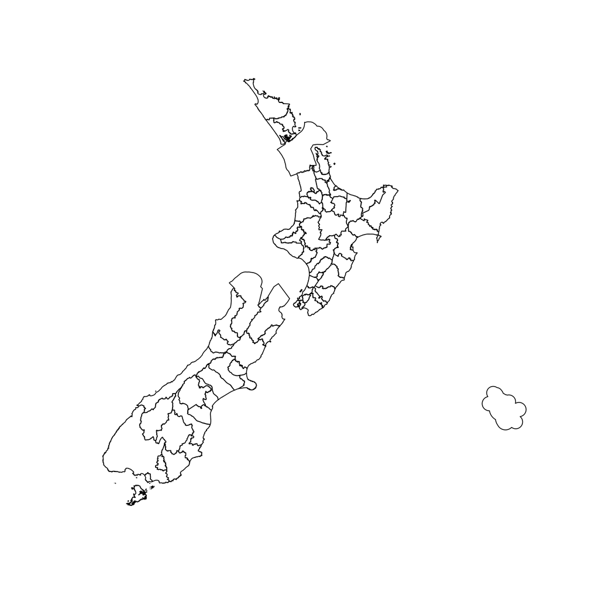

```r
shape <- shape %>%
  rename(
    TA_CODE = TA2018_V1_,
    TA_NAME = TA2018_V_1
  ) %>%
  filter(TA_CODE != "999")

shape %>%
  st_geometry() %>%
  plot()
```

## 代码检查与属性连接

两侧检查漏接和重复，再按 `TA_CODE` 作一对一左连接；地区对应不依赖行顺序。

```r
setdiff(shape$TA_CODE, mycsv$TA_CODE)
```

```
## character(0)
```

```r
setdiff(mycsv$TA_CODE, shape$TA_CODE)
```

```
## character(0)
```

```r
nrow(shape)
```

```
## [1] 67
```

```r
anyDuplicated(shape$TA_CODE)
```

```
## [1] 0
```

```r
gis_unique(shape, "TA_CODE")
gis_unique(mycsv, "TA_CODE")
shape2 <- dplyr::left_join(
  shape,
  mycsv,
  by = "TA_CODE",
  relationship = "one-to-one"
)
stopifnot(nrow(shape2) == nrow(shape))
```

### 连接核对

检查行数、人数缺失和 Auckland 代码 `076` 的名称及值，保留原表与连接表供对照。

```r
shape %>%
  head(., n = 10)
```

```
## Simple feature collection with 10 features and 5 fields
## Geometry type: MULTIPOLYGON
## Dimension:     XY
## Bounding box:  xmin: 1735093 ymin: 5410973 xmax: 1908083 ymax: 5568156
## Projected CRS: NZGD2000 / New Zealand Transverse Mercator 2000
##    TA_CODE               TA_NAME LAND_AREA_ AREA_SQ_KM Shape_Leng
## 1      040 Palmerston North City   394.7047   394.7047  108292.59
## 2      041      Tararua District  4364.5765  4364.5765  421712.16
## 3      042   Horowhenua District  1063.9908  1063.9908  160856.34
## 4      043 Kapiti Coast District   731.5000   731.5000  185797.70
## 5      044          Porirua City   174.8098   182.4483   89301.89
## 6      045       Upper Hutt City   539.8690   539.8690  128058.85
## 7      046       Lower Hutt City   376.4034   376.5317  128656.47
## 8      047       Wellington City   289.7760   289.9122  130029.74
## 9      048    Masterton District  2300.1960  2300.1960  332320.51
## 10     049    Carterton District  1179.9690  1179.9690  322243.46
##                          geometry
## 1  MULTIPOLYGON (((1822620 553...
## 2  MULTIPOLYGON (((1867148 556...
## 3  MULTIPOLYGON (((1793504 552...
## 4  MULTIPOLYGON (((1782624 549...
## 5  MULTIPOLYGON (((1762481 545...
## 6  MULTIPOLYGON (((1779683 546...
## 7  MULTIPOLYGON (((1765759 544...
## 8  MULTIPOLYGON (((1750793 544...
## 9  MULTIPOLYGON (((1862314 549...
## 10 MULTIPOLYGON (((1804926 548...
```

```r
shape2 %>%
  head(., n = 10)
```

```
## Simple feature collection with 10 features and 7 fields
## Geometry type: MULTIPOLYGON
## Dimension:     XY
## Bounding box:  xmin: 1735093 ymin: 5410973 xmax: 1908083 ymax: 5568156
## Projected CRS: NZGD2000 / New Zealand Transverse Mercator 2000
##    TA_CODE               TA_NAME LAND_AREA_ AREA_SQ_KM Shape_Leng
## 1      040 Palmerston North City   394.7047   394.7047  108292.59
## 2      041      Tararua District  4364.5765  4364.5765  421712.16
## 3      042   Horowhenua District  1063.9908  1063.9908  160856.34
## 4      043 Kapiti Coast District   731.5000   731.5000  185797.70
## 5      044          Porirua City   174.8098   182.4483   89301.89
## 6      045       Upper Hutt City   539.8690   539.8690  128058.85
## 7      046       Lower Hutt City   376.4034   376.5317  128656.47
## 8      047       Wellington City   289.7760   289.9122  130029.74
## 9      048    Masterton District  2300.1960  2300.1960  332320.51
## 10     049    Carterton District  1179.9690  1179.9690  322243.46
##              CENSUS_NAME PAID_EMP_2018                       geometry
## 1  Palmerston North City         37683 MULTIPOLYGON (((1822620 553...
## 2       Tararua District          6498 MULTIPOLYGON (((1867148 556...
## 3    Horowhenua District         11901 MULTIPOLYGON (((1793504 552...
## 4  Kapiti Coast District         19791 MULTIPOLYGON (((1782624 549...
## 5           Porirua City         24396 MULTIPOLYGON (((1762481 545...
## 6        Upper Hutt City         20181 MULTIPOLYGON (((1779683 546...
## 7        Lower Hutt City         47634 MULTIPOLYGON (((1765759 544...
## 8        Wellington City        102927 MULTIPOLYGON (((1750793 544...
## 9     Masterton District         10314 MULTIPOLYGON (((1862314 549...
## 10    Carterton District          3570 MULTIPOLYGON (((1804926 548...
```

```r
nrow(shape2)
```

```
## [1] 67
```

```r
sum(is.na(shape2$PAID_EMP_2018))
```

```
## [1] 0
```

```r
shape2 %>%
  st_drop_geometry() %>%
  filter(TA_CODE == "076") %>%
  select(TA_CODE, TA_NAME, CENSUS_NAME, PAID_EMP_2018)
```

```
##   TA_CODE  TA_NAME CENSUS_NAME PAID_EMP_2018
## 1     076 Auckland    Auckland        691473
```

## 受薪雇员人数地图

`Paid employee` 统计普查通常居住人口中 15 岁及以上就业者的受薪雇员人数，按居住地汇总，不是就业率、工资或当地岗位数。就业状态对应 2018 年 3 月 4 日结束的前七天。

```r
tmap_mode("plot")
```

```
## ℹ tmap modes "plot" - "view"
## ℹ toggle with `tmap::ttm()`
```

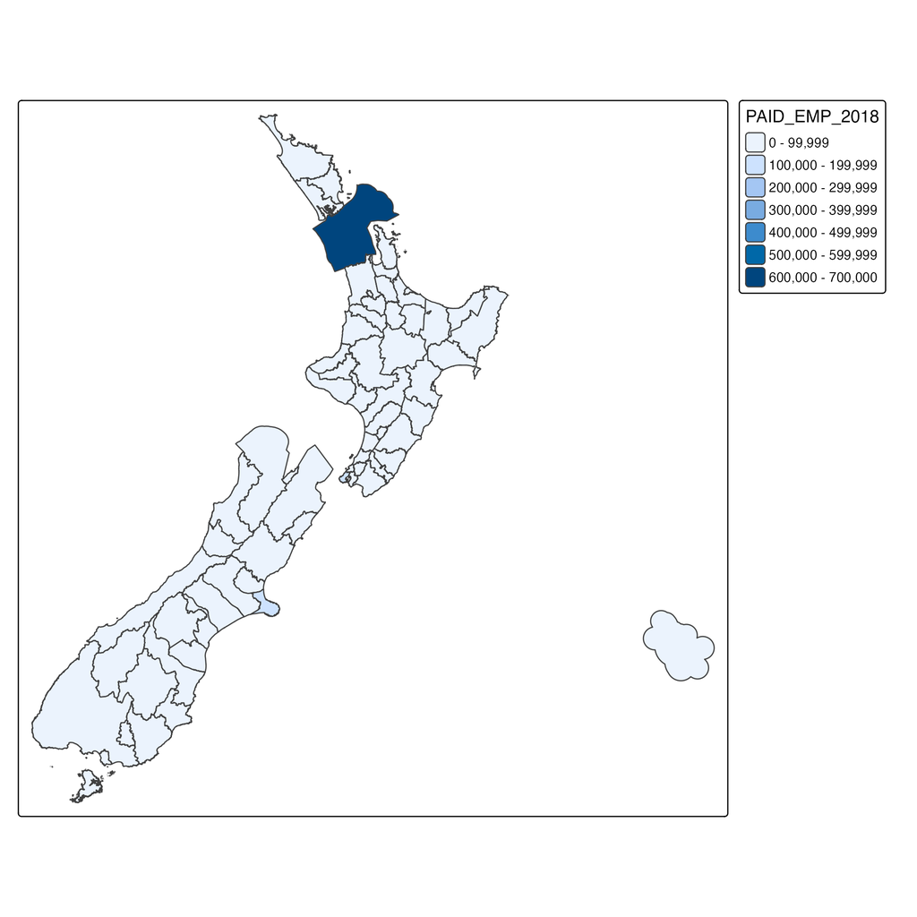

```r
nz_map <- shape2 %>%
  qtm(., fill = "PAID_EMP_2018")

nz_map
```

### 数值排序核对

人数差异受到人口规模影响，色阶不直接表达就业机会。普查计数采用以 3 为基数的固定随机舍入，分项之和可能不同于发布总计。

```r
mycsv %>%
  arrange(desc(PAID_EMP_2018)) %>%
  head(n = 5)
```

```
## # A tibble: 5 × 3
##   TA_CODE CENSUS_NAME       PAID_EMP_2018
##   <chr>   <chr>                     <dbl>
## 1 076     Auckland                 691473
## 2 060     Christchurch City        171777
## 3 047     Wellington City          102927
## 4 016     Hamilton City             71397
## 5 023     Tauranga City             55461
```

## 可选导出

CSV 保存属性，GPKG 保存几何与属性，PNG 保存制图外观。以下导出不随 Knit 自动执行；固定目标文件名会重复使用，GPKG 的 `delete_layer=TRUE` 会替换指定结果图层。原始数据路径不用于导出。

```r
processed_dir <- file.path(root, "week01/data/processed")
figures_dir <- file.path(root, "week01/figures")
reports_dir <- file.path(root, "week01/outputs")

dir.create(processed_dir, recursive = TRUE, showWarnings = FALSE)
dir.create(figures_dir, recursive = TRUE, showWarnings = FALSE)
dir.create(reports_dir, recursive = TRUE, showWarnings = FALSE)
```

### CSV

```r
csv_file <- file.path(processed_dir, "nz_paid_employee_2018.csv")
write_csv(mycsv, csv_file)
```

### CSV 读回（可选）

代码列显式按文字读入，保留前导零；这是 Excel 读取的替代路线。

```r
mycsv <- read_csv(
  csv_file,
  col_types = cols(
    TA_CODE = col_character(),
    CENSUS_NAME = col_character(),
    PAID_EMP_2018 = col_double()
  )
)
```

### GeoPackage

导出 `shape2`，包含就业属性。QGIS 读取 GPKG 时不自动恢复 tmap 样式；分级字段为 `PAID_EMP_2018`。

```r
gpkg_file <- file.path(processed_dir, "nz_paid_employee_2018.gpkg")

shape2 %>%
  st_write(
    .,
    gpkg_file,
    layer = "nz_territorial_paid_employee_2018",
    delete_layer = TRUE
  )
```

### PNG

使用 `ragg::agg_png`，避免本机默认 Cairo/X11 依赖。8×8 英寸、300 dpi 对应 2400×2400 像素。

```r
png_file <- file.path(figures_dir, "nz_paid_employee_2018.png")

tmap_save(
  nz_map,
  filename = png_file,
  device = ragg::agg_png,
  width = 8,
  height = 8,
  units = "in",
  dpi = 300
)

file.exists(csv_file)
file.exists(gpkg_file)
file.exists(png_file)
```

## HTML 报告

渲染读取文档内的完整流程，报告目录为 `week01/outputs/`。Rmd 是源文档，HTML 是阅读版；该渲染块独立执行。

```r
rmarkdown::render(
  input = file.path(root, "week01/homework.Rmd"),
  output_dir = file.path(root, "week01/outputs")
)
```

## 方法范围

基本图对应官方连接与制图目标；CSV、GPKG、PNG、HTML 是保存形式，不据此新增字数、期限或提交格式。公开作业没有独立指定新西兰 QGIS 流程。原始 Excel、边界及各配套文件保持不变。

字段依据为 `Territorial authority!AL9:AL10`、`A11:B79`、`AL11:AL79`；变量质量、固定随机舍入和就业状态时间见 `Footnotes and symbols!B21`、`B27`、`B35`。

## 来源与改编

- 本周中文教程
- [公开教程 1.2 Homework](https://andrewmaclachlan.github.io/CASA0005repo/geographic-information.html#homework)
- [CASA0005 26/27 Moodle 的 Assessment](https://moodle.ucl.ac.uk/course/view.php?id=62319&section=3#tabs-tree-start)
- [公开教程第一课](https://andrewmaclachlan.github.io/CASA0005repo/geographic-information.html)

中文整理与代码适配使用 AI 辅助；原作者、许可及改编范围见来源与改编范围。